# Study Progress: Subsequent Infections following SARS-CoV-2 in Children

This is a living document that is designed to be saved at any amount of points throughout the study, and can be referenced as a state report document with envisioned timelines, findings so far, decisions that have or have not been made, interesting plots, cohort information, and anlaysis information.

# Study progress as of Jan 22nd, 2024

## Cohort

Cohort Design:

Inclusion Criteria:

COVID cohort:

1. Children < 5 years of age at time of first test date or COVID code within the study period
2. SARS-CoV-2 positive by antigen or PCR or COVID-specific diagnosis code or MIS-C/PASC code, with index date imputed if not available to 60 days before
3. At least 1 prior visit in the preceding 18 months to define active population that interacts with health system, or appropriate utilization criteria for infants, and at least one visit during the follow up period 1-6 months after cohort entry date / index date

Influenza comparison cohort:

1. Children < 5 years of age at time of first test date within the study period
2. Evidence of influenza (lab confirmed or diagnosis code)
3. At least 1 prior visit in the preceding 18 months to define active population that interacts with health system, or appropriate utilization criteria for infants, and at least one visit during the follow up period 1-6 months after cohort entry date / index date

Exclusion Criteria:

1. No serology positive if Influenza patient, or if covid patient, cannot be serology positive before the index covid event
2. No MISC or PASC code if Influenza patient (without covid)

### Cohort entry dates, by group, so far

Cohort with all entry criteria and washout criteria applied. Distributions of cohort entry dates over time, separated by sub cohort group:

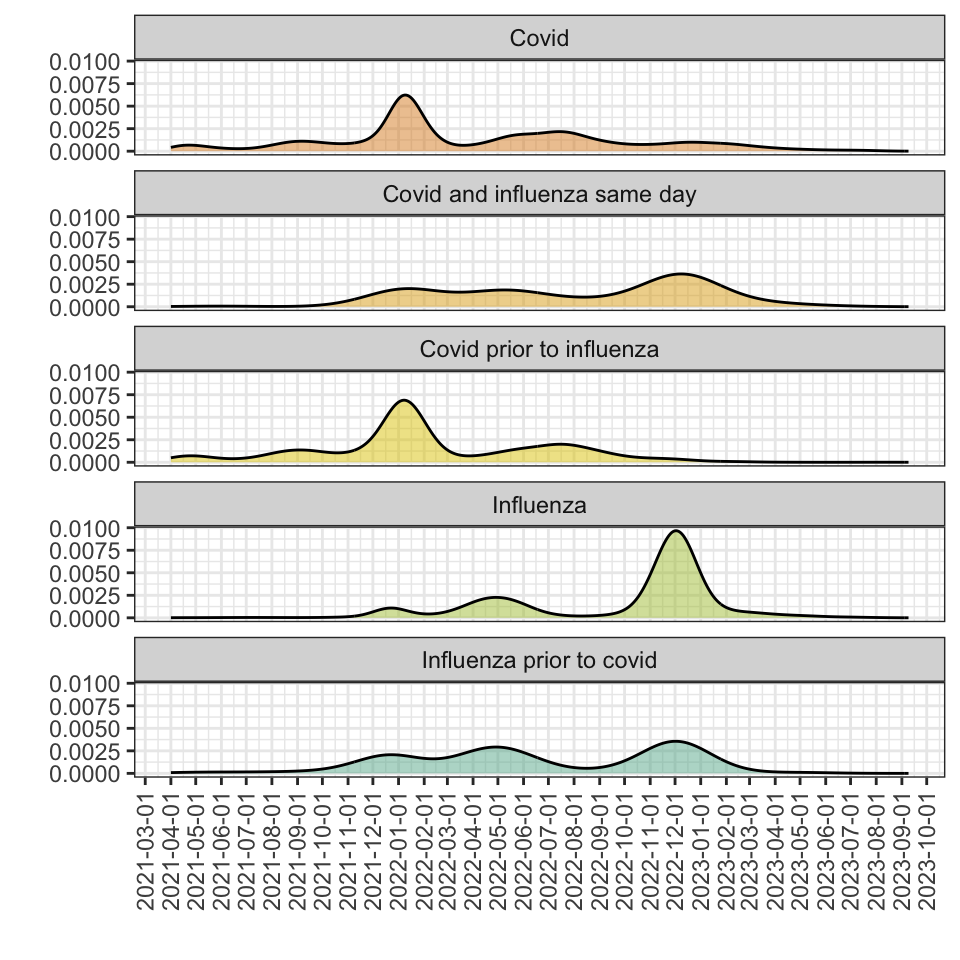

### Timescales for clinical focus

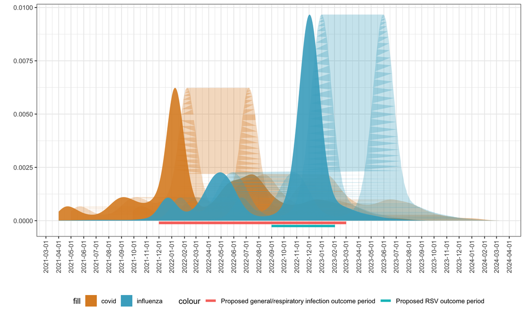

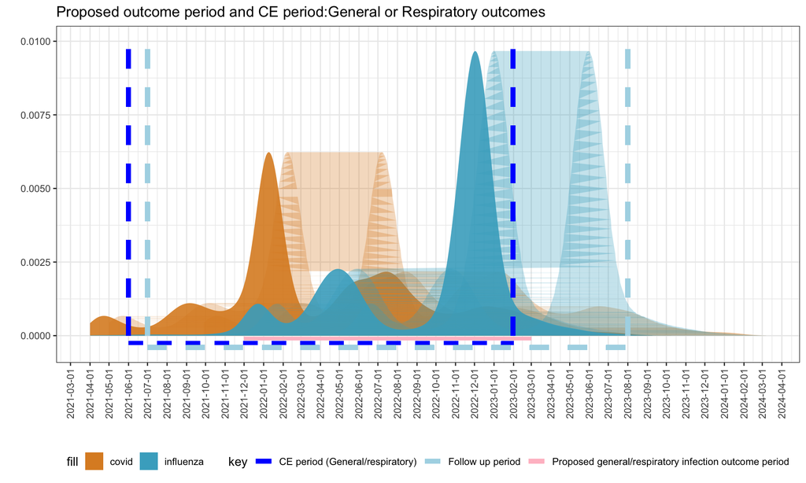

## Codesets

### In development

- RSV – diagnosis `dx_rsv`
- RSV – lab confirmed `lab_rsv`
- Any infection (diagnosis) – `dx_any_infection`
- Influenza (diagnosis) – `dx_influenza`
- Influenza (lab-confirmed) – `lab_influenza_filtered`

### Available

- Respiratory infection – `dx_noncov_resp_infections`

### To do

- Any infection (lab, if possible, but may be way too broad/difficult) – `lab_any_infection`
- Respiratory infection (lab, if possible) – `lab_respiratory`
- Lower respiratory tract infections (may be flag on existing general respiratory codesets, for `dx` and `lab`)
- Injury `dx_injury`
- Poisoning `dx_poisoning`